# POT: Modelling peaks over a threshold

Abstract

“POT: Modelling peaks over a threshold” published in R News.

The Generalised Pareto Distribution (**GPD**) is the limiting distribution of normalised excesses over a threshold, as the threshold approaches the endpoint of the variable (Pickands, 1975). The **POT** package contains useful tools to perform statistical analysis for peaks over a threshold using the GPD approximation.

There is many packages devoted to the extreme value theory (**evd**, **ismev**, **evir**, …); however, the **POT** package is specialised in peaks over threshold analysis. Moreover, this is currently the only one which proposes many estimators for the GPD. A user’s guide (as a package vignette) and two demos are also included in the package.

## Asymptotic Approximation

Let $X_1, \dots, X_n$ be a series of *i.id.* random variables with common distribution function $F$. Let $M_n = \max\{X_1, \dots, X_n\}$. Suppose there exists constants $a_n > 0$ and $b_n$ such that:

$$\mathbb{P} \left[ \frac{M_n - b_n}{a_n}
\leq z \right] \longrightarrow G(z), \quad n \rightarrow
+\infty$$

for $z \in \mathbb{R}$ and where $G$ is a non degenerate distribution function. Then, for $i = 1, \dots, n$, we have:

$$\mathbb{P} [X_i \leq z | X_i > u]
\longrightarrow H(z), \quad u \rightarrow u_{\text{end}} \quad
(1)$$

with

$$H(y) = 1 - \left( 1 + \xi \frac{y -
\mu}{\sigma} \right)_+^{-1/\xi},$$

where $(\mu, \sigma, \xi)$ are the location, scale and shape parameters respectively, $\sigma > 0$ and $z_+ = \max(z, 0)$ and $u_{\text{end}}$ is the right end-point of the variable $X_i$.

It is usual to fit the GPD to excesses over a (high enough) threshold. Thus we suppose that the asymptotic result given by equation (1) is (approximately) true for the threshold of interest.

## Application: Ardières River at Beaujeu

The *ardieres* data frame containing flood discharges (in $m^3 \cdot s^{-1}$) over a period of 33 years of the Ardières river at Beaujeau (FRANCE) is included in the package. There are NA values in year 1994 as a flood event damaged record instrumentation. We use this dataset as an example for a typical univariate analysis. First, we have to “extract” independent events from the time series and select a suitable threshold such that asymptotic approximation in equation (1) is good enough.

```
library("POT")
data("ardieres")
tmp <- clust(ardieres, 0.85, tim.cond = 7/365,
             clust.max = TRUE)
par(mfrow=c(2,2))
mrlplot(tmp[,"obs"], xlim = c(0.85, 17))
diplot(tmp, u.range = c(0.85, 17))
tcplot(tmp[,"obs"], u.range = c(0.85, 17))
```

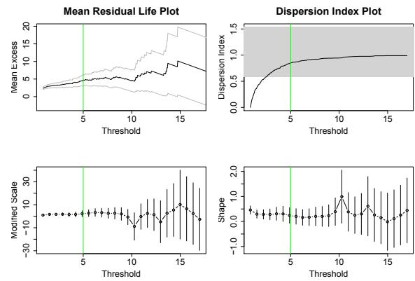

Figure 1: Tools for the threshold selection

The threshold selection stage is a compromise between bias and variance. On one hand, if a too high threshold is selected, the bias decreases as the asymptotic approximation in equation (1) is good enough while the variance increases as there is not enough data above this threshold. On the other hand, by taking a lower threshold, the variance decreases as the number of observations is larger and the bias increases as the asymptotic approximation becomes poorer.

According to Fig. 1, a threshold around five $m^3 \cdot s^{-1}$ should be a “good compromise”. Indeed, the mean residual life plot is “linear” on the range $(5, 7)$; for thresholds greater than 5, the dispersion index estimates are “near” the theoretical value 1; and both modified scale and shape estimates seem to be constant on the range $(5, 9)$. Thus, we select only independent values above this threshold by invoking:

```
events <- clust(ardieres, u = 5,
                tim.cond = 7/365, clust.max = TRUE)
```

```
obs <- events[,"obs"]
pwmu <- fitgpd(obs, thresh = 5, "pwmu")
```

Here is the scale and shape parameter estimates of the GPD for the 7 estimators implemented.

|  | scale | shape |
| --- | --- | --- |
| mle | 2.735991 | 0.2779359 |
| mom | 2.840792 | 0.2465661 |
| pwmu | 2.668368 | 0.2922964 |
| pwmb | 2.704665 | 0.2826697 |
| mdpd | 2.709254 | 0.2915759 |
| med | 2.135882 | 0.8939585 |
| pick | 2.328240 | 0.6648158 |

By invoking:

```
par(mfrow=c(2,2))
plot(pwmu, npy=2.63)
```

we obtain Fig. 2 which depicts graphic tools for model diagnostic. Profile likelihood confidence intervals can also be computed, even for return levels see Fig. 3, with:

```
gpd.pfrl(mle, 0.995, range = c(20, 120),
conf = 0.95)
```

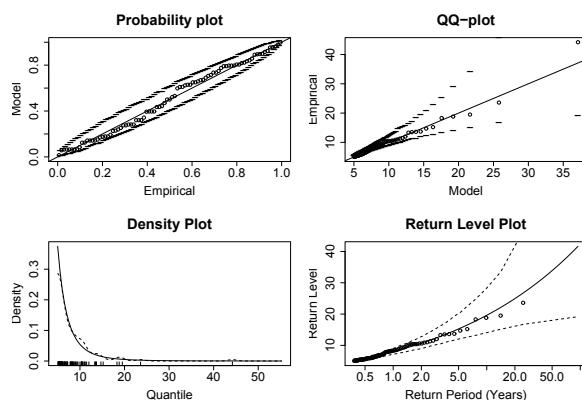

Figure 2: Graphic tools for model diagnostic.

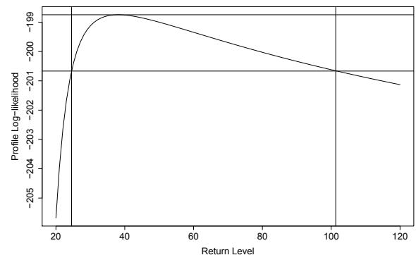

Figure 3: 95% profile confidence interval for the return level associated to non exceedance probability 0.995.

## Miscellaneous Features

The **POT** package can also:

- simulate and compute density, quantile and distribution functions for the GPD;
- fit the GPD with a varying threshold using MLE;
- fit the GPD with held fixed parameters using MLE;
- perform analysis of variance for two nested models;
- estimate the extremal index using two estimators;
- display a L-Moment plot (Hosking and Wallis, 1997);
- compute sample L-moments;
- convert non exceedance probabilities to return periods and vice-versa;
- compute “averaged” time series using an average mobile window.

Currently, most of the package developments are devoted to bivariate peaks over threshold. For this purpose, the **POT** package can also:

- fit a bivariate GPD using 6 parametric dependence functions;
- fit a first order Markov chain with a fixed extreme value dependence structure to all threshold exceedances;
- simulate first order Markov chains with a fixed extreme value dependence structure;
- plot the Pickands’ dependence and the spectral density functions.

## References

- L. Peng and A. Welsh. Robust estimation of the generalised Pareto distribution. *Extremes*, 4(1):53–65, 2001.
- J. Pickands. Statistical inference using extreme order statistics. *Annals of Statistics*, 3:119–131, 1975.